# prelim

[output not shown]

1

```
# Implementation Exercise: Work in Progress
```

2

```
### _Return Predictability and Dynamic Asset Allocation: How Often Should Investors Rebalance?_
```

3

```
by _Himanshu Almadi, David E. Rapach, and Anil Suri_
```

# Implementation Exercise: Work in Progress

### *Return Predictability and Dynamic Asset Allocation: How Often Should Investors Rebalance?*

by *Himanshu Almadi, David E. Rapach, and Anil Suri*

[output not shown]

1

```
## 1. Processing data from Bloomberg Terminal
```

## 1. Processing data from Bloomberg Terminal

3

1

```
import pandas as pd
```

2

```
import numpy as np
```

3

```
import matplotlib.pyplot as plt
```

[output not shown]

1

```
def process_xlsx(filename,filetype = 'Bloomberg'):
```

2

```
    """
```

3

```
    process .xlsx files downloaded from Bloomberg and Factset
```

4

```
    """
```

5

```
    if filetype == 'Bloomberg':
```

6

```
        df = pd.read_excel(filename,header=5)
```

7

```
        df.rename(columns = {'Unnamed: 0':'dates'},inplace=True)
```

8

```
        df.loc[:,'Dates']=pd.to_datetime(other_df['Dates'])
```

9

```
    if filetype == 'Bonds':
```

10

```
        df = pd.read_excel(filename,header=3,parser='Date')
```

11

```
    if filetype == 'Bills':
```

12

```
        df = pd.read_excel(filename,header=20,parser='Date')
```

13

```
    return df.reset_index(drop=True)
```

2

1

```
other_df = process_xlsx('others.xlsx')
```

2

```
other_df.head(5)
```

|  | Dates | SPX Index | SPXDIV Index | CPI INDX Index | CT10 Govt | CB3 Govt | MOODCBAA Index | MOODCAAA Index | IP Index |
| --- | --- | --- | --- | --- | --- | --- | --- | --- | --- |
| 0 | NaT | 329.08 | NaN | NaN | NaN | NaN | NaN | NaN | NaN |
| 1 | 1990-02-28 | 331.89 | NaN | 128.0 | NaN | NaN | 10.14 | 9.22 | 64.0446 |
| 2 | 1990-03-30 | 339.94 | 0.31 | 128.6 | NaN | NaN | 10.21 | 9.37 | 64.3580 |
| 3 | 1990-04-30 | 330.80 | 0.98 | 128.9 | NaN | NaN | 10.30 | 9.46 | 64.2602 |
| 4 | 1990-05-31 | 361.23 | 2.74 | 129.1 | NaN | NaN | 10.41 | 9.47 | 64.3973 |

2

1

```
df_tmp = process_xlsx('./facset/US10YY-TU1.xlsx','Bonds')
```

2

[output not shown]

1

1

```
df_tmp2 = process_xlsx('./facset/TRYUS3M-FDS.xlsx','Bills')
```

2

[output not shown]

[output not shown]

1

```
## 2. Processing Explanatory Variables
```

## 2. Processing Explanatory Variables

1

1

```
### 2.1 log(D/P)
```

### 2.1 log(D/P)

5

1

```
More specifically, I am computing the following:
```

2

```
$$ log(\sum_{s=1}^{12} D_{t-(s-1)}) - log(P_{t}) $$
```

3

```
where `D` stands for dividens paid by `SP500` constituents at time t.
```

4

```
And `P` stands for `SP500` at time t.
```

5

More specifically, I am computing the following:

$$log(\sum_{s=1}^{12} D_{t-(s-1)}) - log(P_{t})$$
where `D` stands for dividens paid by `SP500` constituents at time t. And `P` stands for `SP500` at time t.

1

1

```
As a sanity check, I wanted to check there are only two `NaN` values for `SPXDIV Index`
```

As a sanity check, I wanted to check there are only two `NaN` values for `SPXDIV Index`

1

1

```
other_df['SPXDIV Index'].isna().sum()
```

```
2
```

1

1

```
other_df.head()
```

|  | Dates | SPX Index | SPXDIV Index | CPI INDX Index | CT10 Govt | CB3 Govt | MOODCBAA Index | MOODCAAA Index | IP Index |
| --- | --- | --- | --- | --- | --- | --- | --- | --- | --- |
| 0 | NaT | 329.08 | NaN | NaN | NaN | NaN | NaN | NaN | NaN |
| 1 | 1990-02-28 | 331.89 | NaN | 128.0 | NaN | NaN | 10.14 | 9.22 | 64.0446 |
| 2 | 1990-03-30 | 339.94 | 0.31 | 128.6 | NaN | NaN | 10.21 | 9.37 | 64.3580 |
| 3 | 1990-04-30 | 330.80 | 0.98 | 128.9 | NaN | NaN | 10.30 | 9.46 | 64.2602 |
| 4 | 1990-05-31 | 361.23 | 2.74 | 129.1 | NaN | NaN | 10.41 | 9.47 | 64.3973 |

2

1

```
df['log_DP'] = (other_df['SPXDIV Index'].rolling(12).sum().apply('log').shift()
```

2

```
                - other_df['SPX Index'].apply('log'))
```

1

1

```
df[['Dates','log_DP']][13:].head()
```

|  | Dates | log_DP |
| --- | --- | --- |
| 13 | 1991-02-28 | NaN |
| 14 | 1991-03-29 | -3.184739 |
| 15 | 1991-04-30 | -3.187664 |
| 16 | 1991-05-31 | -3.221650 |
| 17 | 1991-06-28 | -3.175793 |

[output not shown]

1

```
Compare 14th row with following for sanity check:
```

Compare 14th row with following for sanity check:

1

1

```
np.log(sum(other_df['SPXDIV Index'][2:14])) - np.log(other_df['SPX Index'][14])
```

```
-3.1847388834548687
```

1

1

```
### 2.2 Inflation
```

### 2.2 Inflation

10

1

```
Inflation is calculated by CPI Index. The research paper writes following:
```

2

```
<br>
```

3

```
_We account for the delay in the release of monthly CPI data when computing the forecast_
```

4

```
<br>
```

5

```
My susequent search suggested that  CPI Index is released with lag of 1 month.
```

6

```
<br>
```

7

```
Thus, I adjust for the issue by shifting CPI Index level by 1.
```

8

```
$$ inflation_{t} = \frac{CPI_{t}}{CPI_{t-1}}$$
```

9

```
However, at time t, the most recent available inflation rate is that of time t-1.
```

10

Inflation is calculated by CPI Index. The research paper writes following:  
*We account for the delay in the release of monthly CPI data when computing the forecast*  
My susequent search suggested that CPI Index is released with lag of 1 month.  
Thus, I adjust for the issue by shifting CPI Index level by 1.

$$inflation_{t} = \frac{CPI_{t}}{CPI_{t-1}}$$
However, at time t, the most recent available inflation rate is that of time t-1.

1

1

```
df['inflation'] = other_df['CPI INDX Index'].pct_change().shift()
```

1

1

```
df[['Dates','inflation']].head()
```

|  | Dates | inflation |
| --- | --- | --- |
| 0 | NaT | NaN |
| 1 | 1990-02-28 | NaN |
| 2 | 1990-03-30 | NaN |
| 3 | 1990-04-30 | 0.004687 |
| 4 | 1990-05-31 | 0.002333 |

```
xxxxxxxxxx
```

1

```
Following is a sanity check. inflation rate for 2nd row is consistent with third row of inflation columns. The rationale for this is explained at the Markdown Cell above
```

Following is a sanity check. inflation rate for 2nd row is consistent with third row of inflation columns. The rationale for this is explained at the Markdown Cell above

1

1

```
(other_df['CPI INDX Index'][2]/other_df['CPI INDX Index'][1] -1)
```

```
0.004687499999999956
```

```
x
```

1

```
### 2.3 Term Spread
```

### 2.3 Term Spread

```
xxxxxxxxxx
```

1

```
Term spread refers to the difference between 10-year Treasury bond yield and the three-month Treasury bill yield.
```

2

```
<br>
```

3

```
When I retrieved data from the Bloomberg Terminal, I requested quotes for `USGG10YR Index` and `USGG3M Index`. However, I need to get confirmation about whether this is indeed the data I was after.
```

Term spread refers to the difference between 10-year Treasury bond yield and the three-month Treasury bill yield.  
When I retrieved data from the Bloomberg Terminal, I requested quotes for `USGG10YR Index` and `USGG3M Index`. However, I need to get confirmation about whether this is indeed the data I was after.

1

1

```
bonds_df.keys()
```

```
Index(['Dates', 'USGG3M Index', 'USGG10YR Index'], dtype='object')
```

1

1

```
df['Term_Spread'] = bonds_df[bonds_df.keys()[2]]-bonds_df[bonds_df.keys()[1]]
```

1

1

```
df[['Dates','Term_Spread']].head()
```

|  | Dates | Term_Spread |
| --- | --- | --- |
| 0 | NaT | NaN |
| 1 | 1990-02-28 | 0.485 |
| 2 | 1990-03-30 | 0.584 |
| 3 | 1990-04-30 | 0.990 |
| 4 | 1990-05-31 | 0.581 |

```
xxxxxxxxxx
```

1

```
A few observations would be sufficient for a sanity check as it only requires a subtraction
```

A few observations would be sufficient for a sanity check as it only requires a subtraction

1

1

```
bonds_df.head()
```

|  | Dates | USGG3M Index | USGG10YR Index |
| --- | --- | --- | --- |
| 0 | NaT | 8.009 | NaN |
| 1 | 1990-02-28 | 8.030 | 8.515 |
| 2 | 1990-03-30 | 8.044 | 8.628 |
| 3 | 1990-04-30 | 8.032 | 9.022 |
| 4 | 1990-05-31 | 8.018 | 8.599 |

1

1

```
### 2.4 Default Spread
```

### 2.4 Default Spread

```
xxxxxxxxxx
```

1

```
The difference between Moody's BAA and AAA rated corporate Bond yields
```

The difference between Moody's BAA and AAA rated corporate Bond yields

1

1

```
df['Default_Spread']=other_df['MOODCBAA Index'] - other_df['MOODCAAA Index']
```

1

1

```
df[['Dates','Default_Spread']].head()
```

|  | Dates | Default_Spread |
| --- | --- | --- |
| 0 | NaT | NaN |
| 1 | 1990-02-28 | 0.92 |
| 2 | 1990-03-30 | 0.84 |
| 3 | 1990-04-30 | 0.84 |
| 4 | 1990-05-31 | 0.94 |

```
xxxxxxxxxx
```

1

```
As with `term spread`, a few observation would be sufficient for a sanity check as it only requires a subtraction
```

As with `term spread`, a few observation would be sufficient for a sanity check as it only requires a subtraction

1

1

```
other_df[['Dates','MOODCBAA Index','MOODCAAA Index']].head()
```

|  | Dates | MOODCBAA Index | MOODCAAA Index |
| --- | --- | --- | --- |
| 0 | NaT | NaN | NaN |
| 1 | 1990-02-28 | 10.14 | 9.22 |
| 2 | 1990-03-30 | 10.21 | 9.37 |
| 3 | 1990-04-30 | 10.30 | 9.46 |
| 4 | 1990-05-31 | 10.41 | 9.47 |

1

1

```
### 2.5  Moving Averages
```

### 2.5 Moving Averages

```
xxxxxxxxxx
```

1

```
Average of `SPX Index` for the past 12-months.
```

2

```
<br>
```

3

```
$$ MA_{t} = \frac{\sum_{i=0}^{11} SPX_{t-i}}{12}$$
```

Average of `SPX Index` for the past 12-months.

$$MA_{t} = \frac{\sum_{i=0}^{11} SPX_{t-i}}{12}$$

1

1

```
Moving_Average_12 = other_df['SPX Index'].rolling(12).mean()
```

1

1

```
Moving_Average_12[10:].head()
```

```
10           NaN
11    332.680000
12    333.917500
13    336.849167
14    339.789167
Name: SPX Index, dtype: float64
```

1

1

```
As a sanity check: the moving average of first 12 numbers are as following:
```

As a sanity check: the moving average of first 12 numbers are as following:

1

1

```
np.mean(other_df['SPX Index'][:12])
```

```
332.68000000000006
```

1

1

```
Moving_Average_2 = other_df['SPX Index'].rolling(2).mean()
```

1

1

```
Moving_Average_2.head()
```

```
0        NaN
1    330.485
2    335.915
3    335.370
4    346.015
Name: SPX Index, dtype: float64
```

1

1

[output not shown]

1

1

```
np.mean(other_df['SPX Index'][:2])
```

```
330.485
```

1

1

```
Bond_Moving_Average_12 = bonds_df['USGG10YR Index'].rolling(12).mean()
```

1

1

```
Bond_Moving_Average_12[10:].head()
```

```
10         NaN
11         NaN
12    8.508417
13    8.468250
14    8.421000
Name: USGG10YR Index, dtype: float64
```

1

1

```
As a sanity check: the moving average of first 12 numbers are as following:
```

As a sanity check: the moving average of first 12 numbers are as following:

1

1

```
np.mean(bonds_df['USGG10YR Index'][1:13])
```

```
8.508416666666667
```

1

1

```
Bond_Moving_Average_6 = bonds_df['USGG10YR Index'].rolling(6).mean()
```

1

1

```
Bond_Moving_Average_6[5:].head()
```

```
5         NaN
6    8.586167
7    8.641333
8    8.669167
9    8.601667
Name: USGG10YR Index, dtype: float64
```

1

1

```
np.mean(bonds_df['USGG10YR Index'][1:7])
```

```
8.586166666666665
```

```
x
```

1

```
### 2.5.1 MA(1,12)
```

### 2.5.1 MA(1,12)

3

1

```
It is a dummy variable based on `SPX Index` level and `Moving_Average_12`
```

2

```
<br>
```

3

```
If `SPX Index` value is greater than its 12 months moving average, then assign 1. Otherwise assign 0.
```

It is a dummy variable based on `SPX Index` level and `Moving_Average_12`  
If `SPX Index` value is greater than its 12 months moving average, then assign 1. Otherwise assign 0.

1

1

```
MA_nan = (other_df['SPX Index']-Moving_Average_12).apply(lambda x: np.nan if np.isnan(x) else 0)
```

1

1

```
df['MA_1_12']=(other_df['SPX Index']-Moving_Average_12).apply(lambda x: 1 if x>0 else 0) + MA_nan
```

1

1

```
df[['Dates','MA_1_12']][9:].head()
```

|  | Dates | MA_1_12 |
| --- | --- | --- |
| 9 | 1990-10-31 | NaN |
| 10 | 1990-11-30 | NaN |
| 11 | 1990-12-31 | 0.0 |
| 12 | 1991-01-31 | 1.0 |
| 13 | 1991-02-28 | 1.0 |

```
x
```

1

```
As a sanity check, since Moving_Average_12 is already checked, following shows that lambda function performs as expected.
```

As a sanity check, since Moving_Average_12 is already checked, following shows that lambda function performs as expected.

1

1

```
(other_df['SPX Index']-Moving_Average_12)[9:].head()
```

```
9           NaN
10          NaN
11    -2.460000
12    10.012500
13    30.220833
Name: SPX Index, dtype: float64
```

```
x
```

1

```
### 2.5.2 MA(2,12)
```

### 2.5.2 MA(2,12)

3

1

```
It is a dummy variable based on `Moving_Average_2`  and `Moving_Average_12`
```

2

```
<br>
```

3

```
If `Moving_Average_2` value is greater than `Moving_Average_12` value, then assign 1. Otherwise assign 0.
```

It is a dummy variable based on `Moving_Average_2` and `Moving_Average_12`  
If `Moving_Average_2` value is greater than `Moving_Average_12` value, then assign 1. Otherwise assign 0.

1

1

```
df['MA_2_12']=(Moving_Average_2-Moving_Average_12).apply(lambda x: 1 if x>0 else 0) + MA_nan
```

1

1

```
df[['Dates','MA_2_12']][9:].head()
```

|  | Dates | MA_2_12 |
| --- | --- | --- |
| 9 | 1990-10-31 | NaN |
| 10 | 1990-11-30 | NaN |
| 11 | 1990-12-31 | 0.0 |
| 12 | 1991-01-31 | 1.0 |
| 13 | 1991-02-28 | 1.0 |

```
x
```

1

```
### 2.5.3 MOMBY(6)
```

### 2.5.3 MOMBY(6)

```
xxxxxxxxxx
```

1

```
It is a dummy variable based on `Bond_Moving_Average_6`  and the current bond yield.
```

2

```
<br>
```

3

```
If the bond yield is greater than `Bond_Moving_Average_6` by more than 5 basis points, assign -1.
```

4

```
<br>
```

5

[output not shown]

6

```
<br>
```

7

```
Otherwie, assign 0.
```

2

1

```
MOMBY_6_nan = (bonds_df['USGG10YR Index']-Bond_Moving_Average_6
```

2

```
              ).apply(lambda x: np.nan if np.isnan(x) else 0)
```

2

1

```
df['MOMBY_6']=(bonds_df['USGG10YR Index']-Bond_Moving_Average_6
```

2

```
              ).apply(lambda x: -1 if x>0.05 else (1 if x<0.05 else 0)) + MOMBY_6_nan
```

1

1

```
df[['Dates','MOMBY_6']][5:].head()
```

|  | Dates | MOMBY_6 |
| --- | --- | --- |
| 5 | 1990-06-29 | NaN |
| 6 | 1990-07-31 | 1.0 |
| 7 | 1990-08-31 | -1.0 |
| 8 | 1990-09-28 | -1.0 |
| 9 | 1990-10-31 | 1.0 |

```
xxxxxxxxxx
```

1

```
### 2.5.3 MOMBY(12)
```

### 2.5.3 MOMBY(12)

2

1

```
MOMBY_12_nan = (bonds_df['USGG10YR Index']-Bond_Moving_Average_12
```

2

```
              ).apply(lambda x: np.nan if np.isnan(x) else 0)
```

2

1

```
df['MOMBY_12']=(bonds_df['USGG10YR Index']-Bond_Moving_Average_12
```

2

```
              ).apply(lambda x: -1 if x>0.05 else (1 if x<0.05 else 0)) + MOMBY_12_nan
```

1

1

```
df[['Dates','MOMBY_12']][11:].head()
```

|  | Dates | MOMBY_12 |
| --- | --- | --- |
| 11 | 1990-12-31 | NaN |
| 12 | 1991-01-31 | 1.0 |
| 13 | 1991-02-28 | 1.0 |
| 14 | 1991-03-29 | 1.0 |
| 15 | 1991-04-30 | 1.0 |

1

1

```
### 2.6 MOM
```

### 2.6 MOM

```
xxxxxxxxxx
```

1

```
It is a dummy variable that depends on `SPX Index` and its lagged values.
```

It is a dummy variable that depends on `SPX Index` and its lagged values.

```
x
```

1

```
### 2.6.1 MOM(9)
```

2

```
If the difference between `SPX Index` and its 9 months lagged value is positive then assign 1. Otherwise assign 0.
```

### 2.6.1 MOM(9)

If the difference between `SPX Index` and its 9 months lagged value is positive then assign 1. Otherwise assign 0.

4

1

```
MOM_9_nan = (other_df['SPX Index']-other_df['SPX Index'].shift(9)
```

2

```
            ).apply(lambda x: np.nan if np.isnan(x) else 0)
```

3

```
df['MOM_9']=(other_df['SPX Index']-other_df['SPX Index'].shift(9)
```

4

```
            ).apply(lambda x: 1 if x>0 else 0) + MOM_9_nan
```

1

1

```
df[['Dates','MOM_9']][8:].head()
```

|  | Dates | MOM_9 |
| --- | --- | --- |
| 8 | 1990-09-28 | NaN |
| 9 | 1990-10-31 | 0.0 |
| 10 | 1990-11-30 | 0.0 |
| 11 | 1990-12-31 | 0.0 |
| 12 | 1991-01-31 | 1.0 |

```
xxxxxxxxxx
```

1

```
Following checks the result
```

Following checks the result

1

1

```
(other_df['SPX Index']-other_df['SPX Index'].shift(9))[8:].head()
```

```
8       NaN
9    -25.08
10    -9.67
11    -9.72
12    13.13
Name: SPX Index, dtype: float64
```

2

1

```
### 2.6.2 MOM(12)
```

2

```
If the difference between `SPX Index` and its 12 months lagged value is positive then assign 1. Otherwise assign 0.
```

### 2.6.2 MOM(12)

If the difference between `SPX Index` and its 12 months lagged value is positive then assign 1. Otherwise assign 0.

4

1

```
MOM_12_nan = (other_df['SPX Index']-other_df['SPX Index'].shift(12)
```

2

```
            ).apply(lambda x: np.nan if np.isnan(x) else 0)
```

3

```
df['MOM_12']=(other_df['SPX Index']-other_df['SPX Index'].shift(12)
```

4

```
            ).apply(lambda x: 1 if x>0 else 0) + MOM_12_nan
```

1

1

```
df[['Dates','MOM_12']][11:].head()
```

|  | Dates | MOM_12 |
| --- | --- | --- |
| 11 | 1990-12-31 | NaN |
| 12 | 1991-01-31 | 1.0 |
| 13 | 1991-02-28 | 1.0 |
| 14 | 1991-03-29 | 1.0 |
| 15 | 1991-04-30 | 1.0 |

```
x
```

1

```
### 2.7 Output Gap
```

### 2.7 Output Gap

```
x
```

1

```
The deviation of the log of industrial production from a quadratic trend.
```

2

```
<br>
```

3

```
I believe this data is available from Bloomberg Terminal.
```

4

```
However, it is simple to compute. Therefore, I decided to simply compute it.
```

5

```
<br>
```

6

```
A quadratic trend is of the following form:
```

7

```
<br>
```

8

```
$$ y_{t} = \beta_{0} + \beta_{0}x_{t} + \beta_{0}x_{t}^2 +\epsilon_{t} $$
```

9

```
<br>
```

10

```
$\widehat{\beta}$ is estimated by $$\widehat{\beta} = (X^{T}X)^{-1}X^{T}y  $$
```

11

12

```
following provides an illustration of this estimation procedure.
```

13

14

The deviation of the log of industrial production from a quadratic trend.  
I believe this data is available from Bloomberg Terminal. However, it is simple to compute. Therefore, I decided to simply compute it.  
A quadratic trend is of the following form:

$$y_{t} = \beta_{0} + \beta_{0}x_{t} + \beta_{0}x_{t}^2 +\epsilon_{t}$$
$\widehat{\beta}$ is estimated by
$$\widehat{\beta} = (X^{T}X)^{-1}X^{T}y$$

following provides an illustration of this estimation procedure.

10

1

```
def beta_est(obs):
```

2

```
    """
```

3

```
    estimates beta of ols to minimize l2 norm
```

4

```
    """
```

5

```
    y = np.log(other_df['IP Index'].dropna())[:obs]
```

6

```
    X = np.concatenate((np.ones(obs).reshape(-1,1),np.arange(obs).reshape(-1,1)),axis=1)
```

7

```
    X = np.concatenate((X,(np.arange(obs)**2).reshape(-1,1)),axis=1)
```

8

```
    beta_hat = np.dot(np.matmul(np.linalg.inv(1e-6 *np.eye(3) + np.matmul(X.transpose(),X)),
```

9

```
                                X.transpose()),y.values.reshape(-1,1))
```

10

```
    return beta_hat
```

11

1

```
n = len(np.log(other_df['IP Index'].dropna()))
```

2

```
X = np.concatenate((np.ones(n).reshape(-1,1),np.arange(n).reshape(-1,1)),axis=1)
```

3

```
X = np.concatenate((X,(np.arange(n)**2).reshape(-1,1)),axis=1)
```

4

```
y_pred = np.matmul(X,beta_hat)
```

5

```
y = np.log(other_df['IP Index'].dropna())
```

6

```
plot_df = np.concatenate((np.arange(n).reshape(-1,1),y.values.reshape(-1,1),y_pred),axis=1)
```

7

```
plot_df = pd.DataFrame(plot_df)
```

8

```
plot_df.columns = ['obs','log(IP)','predicted log(IP)']
```

9

```
plt.plot('obs','log(IP)',data=plot_df)
```

10

```
plt.plot('obs','predicted log(IP)',data=plot_df)
```

11

```
plt.legend()
```

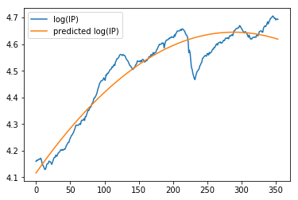

```
xxxxxxxxxx
```

1

```
However, the research estimates $\widehat{\beta}$ from data available up to each point in time. Thus, I will repeat the calculation above to every time step.
```

However, the research estimates $\widehat{\beta}$ from data available up to each point in time. Thus, I will repeat the calculation above to every time step.

5

1

```
def output_gap_computer(obs):
```

2

```
    """
```

3

```
    computes the deviation of the log of industrial production from a quadratic trend.
```

4

```
    """
```

5

```
    return y[obs]-np.dot(X[:obs],beta_est(obs))[-1]
```

5

1

```
# Next Cell parallelize for loop. It is equivalent to
```

2

3

```
# output_gap2 = []
```

4

```
# for i in range(1,n+1):
```

5

```
#     output_gap2 += [output_gap_computer(i)]
```

2

1

```
pool = multiprocessing.Pool(4)
```

2

```
output_gap =[*pool.map(output_gap_computer, range(1, n+1))]
```

1

1

```
df['output_gap']=np.concatenate(([np.nan],np.array(output_gap).reshape(-1)))
```

```
xxxxxxxxxx
```

1

```
### 2.7 SPX Index return
```

2

### 2.7 SPX Index return

2

1

```
df['r_SPX'] = other_df['SPX Index'].pct_change()
```

2

```
df[['Dates','r_SPX']].head()
```

|  | Dates | r_SPX |
| --- | --- | --- |
| 0 | NaT | NaN |
| 1 | 1990-02-28 | 0.008539 |
| 2 | 1990-03-30 | 0.024255 |
| 3 | 1990-04-30 | -0.026887 |
| 4 | 1990-05-31 | 0.091989 |

```
xxxxxxxxxx
```

1

```
### 2.8 Bond return and yield
```

### 2.8 Bond return and yield

10

9

1

```
def compound_return(cum_return):
```

2

```
    sol = (cum_return.values/100 + 1)
```

3

```
    for i in range(2,len(sol)):
```

4

```
       sol[i] = sol[i]/sol[:i].prod()
```

5

```
    return sol - 1
```

6

```
compound_return(df_tmp2['Cumulative Return %'])
```

7

2

1

```
df['y_bond'] = df_tmp['Close']/100
```

2

```
df[['Dates','y_bond']].head()
```

|  | Dates | y_bond |
| --- | --- | --- |
| 0 | NaT | 0.0774 |
| 1 | 1990-02-28 | 0.0777 |
| 2 | 1990-03-30 | 0.0780 |
| 3 | 1990-04-30 | 0.0779 |
| 4 | 1990-05-31 | 0.0775 |

```
x
```

1

```
df['r_bond'] = compound_return(df_tmp['Cumulative Return %'])
```

2

```
df[['Dates','r_bond']].head()
```

|  | Dates | r_bond |
| --- | --- | --- |
| 0 | NaT | 0.000000 |
| 1 | 1990-02-28 | 0.003876 |
| 2 | 1990-03-30 | 0.003861 |
| 3 | 1990-04-30 | -0.001282 |
| 4 | 1990-05-31 | -0.005135 |

```
xxxxxxxxxx
```

1

```
To check the comulative_return function indeed takes cumulative return as input and computes the compounding rate of return: I will manually compute `r_bond` on `1990-03-30`. The numbers correspond to cumulative returns as can be seen from the cell below:
```

2

```
<br>
```

3

```
$$ (1+ 0.007752) = (1 + 0.003876)(1 + r) \Rightarrow r = 0.003861$$
```

4

```
$$ (1 + 0.006460) = (1 + 0.003876)(1 + 0.003861)(1 + r) \Rightarrow r = -0.001282 $$
```

5

6

To check the comulative_return function indeed takes cumulative return as input and computes the compounding rate of return: I will manually compute `r_bond` on `1990-03-30`. The numbers correspond to cumulative returns as can be seen from the cell below:

$$(1+ 0.007752) = (1 + 0.003876)(1 + r) \Rightarrow r = 0.003861$$
$$(1 + 0.006460) = (1 + 0.003876)(1 + 0.003861)(1 + r) \Rightarrow r = -0.001282$$

1

1

```
(df_tmp['Cumulative Return %']/100 + 1).head()
```

```
0    1.000000
1    1.003876
2    1.007752
3    1.006460
4    1.001292
Name: Cumulative Return %, dtype: float64
```

```
xxxxxxxxxx
```

1

[output not shown]

2

1

```
df['y_bill'] = df_tmp['Close']/100
```

2

```
df[['Dates','y_bill']].head()
```

|  | Dates | y_bill |
| --- | --- | --- |
| 0 | NaT | 0.0774 |
| 1 | 1990-02-28 | 0.0777 |
| 2 | 1990-03-30 | 0.0780 |
| 3 | 1990-04-30 | 0.0779 |
| 4 | 1990-05-31 | 0.0775 |

```
x
```

1

```
df['r_bill'] = compound_return(df_tmp['Cumulative Return %'])
```

2

```
df[['Dates','r_bill']].head()
```

|  | Dates | r_bill |
| --- | --- | --- |
| 0 | NaT | 0.000000 |
| 1 | 1990-02-28 | 0.003876 |
| 2 | 1990-03-30 | 0.003861 |
| 3 | 1990-04-30 | -0.001282 |
| 4 | 1990-05-31 | -0.005135 |

```
xxxxxxxxxx
```

1

```
## 3. Return Forecasts
```

## 3. Return Forecasts

1

1

```
After preprocessing available data is from 1991-03-29 to 2019-07-31
```

After preprocessing available data is from 1991-03-29 to 2019-07-31

2

1

```
processed_df = df.loc[14:].reset_index(drop=True)
```

2

```
processed_df.head()
```

|  | Dates | log_DP | inflation | Term_Spread | Default_Spread | MA_1_12 | MA_2_12 | MOMBY_6 | MOMBY_12 | MOM_9 | MOM_12 | output_gap | r_SPX | r_bond | r_bill | y_bond | y_bill |
| --- | --- | --- | --- | --- | --- | --- | --- | --- | --- | --- | --- | --- | --- | --- | --- | --- | --- |
| 0 | 1991-03-29 | -3.184739 | 0.000742 | 2.128 | 1.16 | 1.0 | 1.0 | 1.0 | 1.0 | 1.0 | 1.0 | 0.003305 | 0.022203 | -0.049669 | -0.049669 | 0.0574 | 0.0574 |
| 1 | 1991-04-30 | -3.187664 | 0.000000 | 2.326 | 1.08 | 1.0 | 1.0 | 1.0 | 1.0 | 1.0 | 1.0 | 0.008409 | 0.000346 | -0.040070 | -0.040070 | 0.0551 | 0.0551 |
| 2 | 1991-05-31 | -3.221650 | 0.002226 | 2.366 | 1.00 | 1.0 | 1.0 | 1.0 | 1.0 | 1.0 | 1.0 | 0.015507 | 0.038577 | 0.003630 | 0.003630 | 0.0553 | 0.0553 |
| 3 | 1991-06-28 | -3.175793 | 0.003701 | 2.534 | 0.95 | 1.0 | 1.0 | -1.0 | 1.0 | 1.0 | 1.0 | 0.018247 | -0.047893 | 0.001808 | 0.001808 | 0.0554 | 0.0554 |
| 4 | 1991-07-31 | -3.222907 | 0.002950 | 2.471 | 0.89 | 1.0 | 1.0 | -1.0 | 1.0 | 1.0 | 1.0 | 0.014082 | 0.044859 | -0.001805 | -0.001805 | 0.0553 | 0.0553 |

```
xxxxxxxxxx
```

1

```
### 3.1 Stock Returns
```

### 3.1 Stock Returns

6

1

```
First step is to find truncated PCA for different number of eigenvalues.
```

2

```
<br>
```

3

```
PCA is implemented on the following matrix. Each variable corresponds to a set of observations and hence is a column vector.
```

4

```
<br>
```

5

```
[ $log(\frac{D}{P})$, Inflation, Term Spread, Default Spread, Output Gap, MA(1,12), MA(2,12), MOM(9), MOM(12) ]
```

6

```
<br>
```

First step is to find truncated PCA for different number of eigenvalues.  
PCA is implemented on the following matrix. Each variable corresponds to a set of observations and hence is a column vector.  
[ $log(\frac{D}{P})$, Inflation, Term Spread, Default Spread, Output Gap, MA(1,12), MA(2,12), MOM(9), MOM(12) ]

```
xxxxxxxxxx
```

1

```
Second step is to come up with a decision rule on how to truncate eigenvalues.
```

2

```
The research paper utilizes (1) out-of-sample $R^2$ denoted as $R_{OS}^2$ and (2) Clark and West statistic.
```

3

```
<br>
```

4

```
where
```

5

```
$$R_{OS}^2 = 1 - \frac{\sum_{t=1}^T (r_{t} - \widehat{r}_{t})}{\sum_{t=1}^T (r_{t} - \overline{r}_{t-1})} $$
```

6

```
and
```

7

```
<br>
```

8

```
<br>
```

9

```
$\widehat{r}_{t}$ is the fitted value using data up to t-1
```

10

```
<br>
```

11

```
$\overline{r}_{t-1}$ is the historal average using data upto t-1
```

12

```
<br>
```

13

```
<br>
```

14

```
Apart from $R_{OS}^2$, the paper utilizes Clark and West (2007) test.
```

15

```
<br> Refer: Approximately Normal Tests for Equal Predictive Accuracy in Nested Models.
```

16

```
<br> Clark and West claims that test of mean squared prediction error (MSPE) typically exhibits a stylised pattern. That is, `the MSPE under Null (parsimonious model) is relatively smaller than it is expected to be because of the efficiency of parsimonious model and noises from estimating more parameters`. Therefore, authors propose an alternative hypothesis test as following:
```

17

```
<br>
```

18

```
For the hypothesis testing <br>H0: Parsimonious model (constant) MSPE is equal to or better than that of the larger model, H1: Larger model is better.
```

19

```
$$ \hat{f}_{t+1} = (y_{t+1} - \hat{y}_{\text{pars:} t,t+1})^2 - [(y_{t+1} - \hat{y}_{\text{large:} t,t+1})^2 - (\hat{y}_{\text{pars:} t,t+1} - \hat{y}_{\text{large:} t,t+1})^2] $$
```

20

```
$$ \overline{f} = \frac{1}{T}\sum_{t=1}^{T}\hat{f}_{t+1}$$
```

21

```
$$ s_{\hat{f}-\overline{f}}^2 = \frac{1}{T-1}\sum_{t=1}^{T}(\hat{f}_{t+1}-\overline{f})^2 $$
```

22

23

```
<br>Test statistics is: $$ CW = \frac{\overline{f}}{s_{\hat{f}-\overline{f}}/\sqrt{T}}$$ <br> the mean of $\hat{f}_{t+\tau}$ denoted as $\overline{\hat{f}_{t+\tau}}$ . With 10% significance level, reject null if $\overline{\hat{f}_{t+\tau}}$ > 1.282. With 5% significance level, reject null if $\overline{\hat{f}_{t+\tau}}$ > 1.645. For one step forecast errors, the usual least squares standard errors can be used. For autocorrelated forecast errors, an autocorrelation consistent standard error should be used.
```

Second step is to come up with a decision rule on how to truncate eigenvalues. The research paper utilizes (1) out-of-sample $R^2$ denoted as $R_{OS}^2$ and (2) Clark and West statistic.  
where

$$R_{OS}^2 = 1 - \frac{\sum_{t=1}^T (r_{t} - \widehat{r}_{t})}{\sum_{t=1}^T (r_{t} - \overline{r}_{t-1})}$$
and
$\widehat{r}_{t}$ is the fitted value using data up to t-1
$\overline{r}_{t-1}$ is the historal average using data upto t-1
Apart from $R_{OS}^2$, the paper utilizes Clark and West (2007) test.
Refer: Approximately Normal Tests for Equal Predictive Accuracy in Nested Models.
Clark and West claims that test of mean squared prediction error (MSPE) typically exhibits a stylised pattern. That is, `the MSPE under Null (parsimonious model) is relatively smaller than it is expected to be because of the efficiency of parsimonious model and noises from estimating more parameters`. Therefore, authors propose an alternative hypothesis test as following:
For the hypothesis testing
H0: Parsimonious model (constant) MSPE is equal to or better than that of the larger model, H1: Larger model is better.
$$\hat{f}_{t+1} = (y_{t+1} - \hat{y}_{\text{pars:} t,t+1})^2 - [(y_{t+1} - \hat{y}_{\text{large:} t,t+1})^2 - (\hat{y}_{\text{pars:} t,t+1} - \hat{y}_{\text{large:} t,t+1})^2]$$
$$\overline{f} = \frac{1}{T}\sum_{t=1}^{T}\hat{f}_{t+1}$$
$$s_{\hat{f}-\overline{f}}^2 = \frac{1}{T-1}\sum_{t=1}^{T}(\hat{f}_{t+1}-\overline{f})^2$$

Test statistics is:

$$CW = \frac{\overline{f}}{s_{\hat{f}-\overline{f}}/\sqrt{T}}$$
the mean of $\hat{f}_{t+\tau}$ denoted as $\overline{\hat{f}_{t+\tau}}$ . With 10% significance level, reject null if $\overline{\hat{f}_{t+\tau}}$ > 1.282. With 5% significance level, reject null if $\overline{\hat{f}_{t+\tau}}$ > 1.645. For one step forecast errors, the usual least squares standard errors can be used. For autocorrelated forecast errors, an autocorrelation consistent standard error should be used.

4

1

```
def truncated_PC(X,dim):
```

2

```
    eig, V = np.linalg.eig(np.matmul(X.transpose(),X))
```

3

```
    approx_X =  np.matmul(X,V[:,:dim])
```

4

```
    return approx_X
```

10

1

```
def PC_approx_error(X,dim):
```

2

```
    """
```

3

```
    PC approximation errors in terms of frobenius norms
```

4

```
    """
```

5

```
    eig, V = np.linalg.eig(np.matmul(X.transpose,X))
```

6

```
    approx_A =  np.matmul(np.matmul(V[:,:dim],
```

7

```
                            np.diag(eig[:dim])),
```

8

```
                            V[:,:dim].transpose())
```

9

```
    error = np.linalg.norm(approx_A - A, ord='fro')
```

10

```
    return error
```

9

1

```
def PC_fit(X,r,dim):
```

2

```
    """
```

3

```
    estimates SPX Index return in a way that minimizes l2 norm
```

4

```
    """
```

5

```
    beta = \
```

6

```
    np.matmul(
```

7

```
        np.linalg.inv(1e-6*np.eye(dim) + np.matmul(X.transpose(),X)),
```

8

```
        np.matmul(X.transpose(),r))
```

9

```
    return beta
```

2

1

```
def R_squared_OS(r):
```

2

```
    np.matmul(X.transpose(),X)
```

3

```
xxxxxxxxxx
```

1

```
### 3.1.1 Principle Component Regression
```

### 3.1.1 Principle Component Regression

3

1

```
stock_explanatory_variables = ['log_DP','inflation','Term_Spread','Default_Spread',\
```

2

```
                               'output_gap','MA_1_12','MA_2_12','MOM_9','MOM_12']
```

3

```
X = processed_df[stock_explanatory_variables].values
```

```
xxxxxxxxxx
```

1

```
The plot of PC approximation errors in terms of frobenius norm is as following:
```

The plot of PC approximation errors in terms of frobenius norm is as following:

7

1

```
PC_plot_df = pd.DataFrame([])
```

2

```
PC_plot_df['dim'] = range(3,X.shape[1]+1)
```

3

```
PC_plot_df['approx_error'] = [PC_approx_error(X,dim) for dim \
```

4

```
                               in range(3,X.shape[1]+1)]
```

5

```
plt.plot('dim','approx_error',data=PC_plot_df)
```

6

```
plt.title("Principle Component Approximation of X'X")
```

7

```
plt.legend()
```

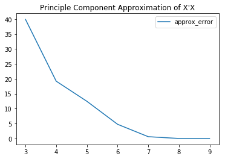

```
xxxxxxxxxx
```

1

```
Above plot confirms that the principle component approximation works as expected
```

Above plot confirms that the principle component approximation works as expected

```
xxxxxxxxxx
```

1

```
Following figures compare actual return with estimated return based on PC regression.
```

Following figures compare actual return with estimated return based on PC regression.

15

1

```
for i in range(3,10):
```

2

```
    dim = i
```

3

```
    r = processed_df['r_SPX'].values
```

4

```
    X_PCA = truncated_PC(X,dim)
```

5

```
    w = PC_fit(X_PCA,r,dim)
```

6

```
    r_hat = np.matmul(X_PCA,w)
```

7

```
    plt.figure(i)
```

8

```
    PC_plot_df2 = pd.DataFrame([])
```

9

```
    PC_plot_df2['r_hat'] = r_hat
```

10

```
    PC_plot_df2['r'] = r
```

11

```
    plt.plot('r',data=PC_plot_df2)
```

12

```
    plt.plot('r_hat',data=PC_plot_df2)
```

13

```
    plt.title(f'Estimated return based on PCA with dimension: {dim}')
```

14

```
    plt.legend()
```

15

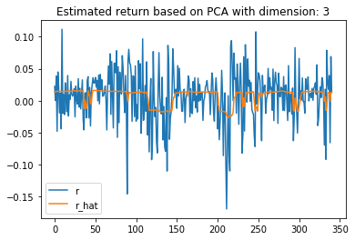

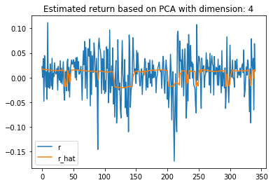

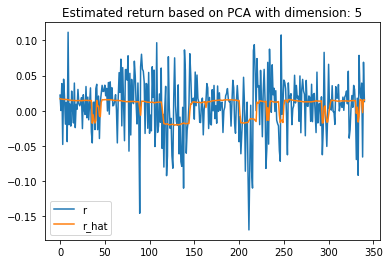

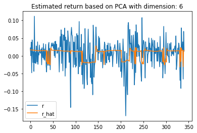

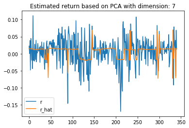

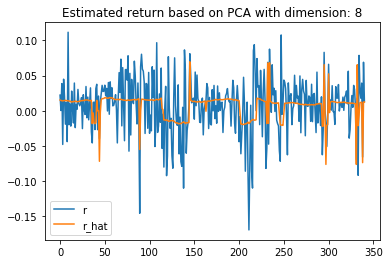

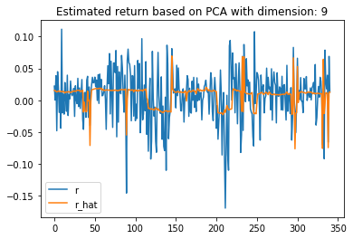

```
x
```

1

```
### 3.1.2  $R_{OS}^2$ Computation
```

### 3.1.2 $R_{OS}^2$ Computation

```
xxxxxxxxxx
```

1

```
Following the logic of the original paper, I will compute $R_{OS}^2$ for monthly (h=1), quartherly (h=3), semi-annual (h=6), and annual (h=12). And out-of-sample forecasts are estimated by recursive estimation windows. For example, for monthly estimation, initial 200 samples are used exclusively for fitting the model. The 201$^{\text{st}}$ sample is forecasted by the model fitted by 200 samples. The 202$^{\text{nd}}$ sample is estimated by the model fitted using 201 samples. And so on.
```

2

```
<br>
```

3

```
<br>
```

4

[output not shown]

12

1

```
def Rsquared_OS(X,r,dim,OS_start):
```

2

```
    numerator = 0
```

3

```
    denominator = 0
```

4

```
    for i in range(OS_start,len(r)):
```

5

```
        X_PCA = truncated_PC(X[:i],dim)
```

6

```
        w = PC_fit(X_PCA,r[:i],dim)
```

7

```
        X_PCA_OS = truncated_PC(X[:i+1],dim)
```

8

```
        r_hat = np.matmul(X_PCA_OS[-1],w)
```

9

```
        numerator += (r[i] - r_hat)**2
```

10

```
        denominator += (r[i]-r[:i].mean())**2
```

11

```
    R_squared_OS = 1 - numerator/denominator
```

12

```
    return R_squared_OS
```

```
xxxxxxxxxx
```

1

```
### 3.1.2.1 Month $R_{OS}^2$
```

### 3.1.2.1 Month $R_{OS}^2$

4

1

```
plt.plot([Rsquared_OS(X,r,i,200) for i in range(X.shape[1]+1)])
```

2

```
plt.xlabel('Rank of Principle Component Approximation')
```

3

```
plt.ylabel('Out-of-sample R-squared')
```

4

```
plt.title('Month out-of-sample R-squared')
```

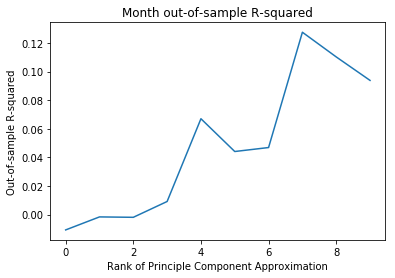

```
xxxxxxxxxx
```

1

```
### 3.1.2.2  Quarter $R_{OS}^2$
```

### 3.1.2.2 Quarter $R_{OS}^2$

```
x
```

1

```
For consistency, I utilized 66 quarterly observations exclusively for fitting the model. Following dataframe shows that 66$^{\text{th}}$ quarterly observation corresponds to 200$^{\text{th}}$ monthly observation.
```

For consistency, I utilized 66 quarterly observations exclusively for fitting the model. Following dataframe shows that 66$^{\text{th}}$ quarterly observation corresponds to 200$^{\text{th}}$ monthly observation.

```
x
```

1

```
processed_df[2:].reset_index().set_index('Dates').resample('3M').agg('last').reset_index()[64:].head()
```

|  | Dates | index | log_DP | inflation | Term_Spread | Default_Spread | MA_1_12 | MA_2_12 | MOMBY_6 | MOMBY_12 | MOM_9 | MOM_12 | output_gap | r_SPX |
| --- | --- | --- | --- | --- | --- | --- | --- | --- | --- | --- | --- | --- | --- | --- |
| 64 | 2007-05-31 | 194 | -3.843610 | 0.003001 | 0.1568 | 0.92 | 1.0 | 1.0 | -1.0 | -1.0 | 1.0 | 1.0 | 0.021707 | 0.032549 |
| 65 | 2007-08-31 | 197 | -3.779418 | 0.001781 | 0.4233 | 0.86 | 1.0 | 1.0 | 1.0 | 1.0 | 1.0 | 1.0 | 0.018905 | 0.012857 |
| 66 | 2007-11-30 | 200 | -3.788723 | 0.003083 | 0.7934 | 0.96 | 1.0 | 1.0 | 1.0 | 1.0 | 1.0 | 1.0 | 0.019589 | -0.044043 |
| 67 | 2008-02-29 | 203 | -3.710938 | 0.003448 | 1.6712 | 1.29 | 0.0 | 0.0 | 1.0 | 1.0 | 0.0 | 0.0 | 0.009492 | -0.034761 |
| 68 | 2008-05-31 | 206 | -3.774398 | 0.002314 | 2.1805 | 1.36 | 0.0 | 0.0 | -1.0 | 1.0 | 0.0 | 0.0 | -0.008239 | 0.010674 |

6

1

```
X_quarter = processed_df[2:].set_index('Dates').resample('3M').agg('last')[stock_explanatory_variables].values
```

2

```
r_quarter = processed_df[2:].set_index('Dates').resample('3M').agg('last')['r_SPX'].values
```

3

```
plt.plot([Rsquared_OS(X_quarter,r_quarter,i,66) for i in range(X.shape[1]+1)])
```

4

```
plt.xlabel('Rank of Principle Component Approximation')
```

5

```
plt.ylabel('Out-of-sample R-squared')
```

6

```
plt.title('Quarter out-of-sample R-squared')
```

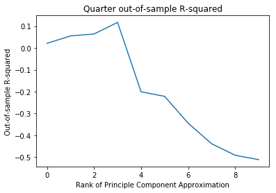

```
xxxxxxxxxx
```

1

```
### 3.1.2.3  Semi-annual $R_{OS}^2$
```

### 3.1.2.3 Semi-annual $R_{OS}^2$

1

1

```
For consistency, I utilized 33 semi-annually observations exclusively for fitting the model. Following dataframe shows that 33$^{\text{rd}}$ quarterly observation corresponds to 200$^{\text{th}}$ monthly observation.
```

For consistency, I utilized 33 semi-annually observations exclusively for fitting the model. Following dataframe shows that 33$^{\text{rd}}$ quarterly observation corresponds to 200$^{\text{th}}$ monthly observation.

1

1

```
processed_df[2:].reset_index().set_index('Dates').resample('6M').agg('last').reset_index()[32:].head()
```

|  | Dates | index | log_DP | inflation | Term_Spread | Default_Spread | MA_1_12 | MA_2_12 | MOMBY_6 | MOMBY_12 | MOM_9 | MOM_12 | output_gap | r_SPX |
| --- | --- | --- | --- | --- | --- | --- | --- | --- | --- | --- | --- | --- | --- | --- |
| 32 | 2007-05-31 | 194 | -3.843610 | 0.003001 | 0.1568 | 0.92 | 1.0 | 1.0 | -1.0 | -1.0 | 1.0 | 1.0 | 0.021707 | 0.032549 |
| 33 | 2007-11-30 | 200 | -3.788723 | 0.003083 | 0.7934 | 0.96 | 1.0 | 1.0 | 1.0 | 1.0 | 1.0 | 1.0 | 0.019589 | -0.044043 |
| 34 | 2008-05-31 | 206 | -3.774398 | 0.002314 | 2.1805 | 1.36 | 0.0 | 0.0 | -1.0 | 1.0 | 0.0 | 0.0 | -0.008239 | 0.010674 |
| 35 | 2008-11-30 | 212 | -3.339371 | -0.008598 | 2.8794 | 3.09 | 0.0 | 0.0 | 1.0 | 1.0 | 0.0 | 0.0 | -0.071761 | -0.074849 |
| 36 | 2009-05-31 | 218 | -3.346824 | 0.001007 | 3.3296 | 2.52 | 0.0 | 0.0 | -1.0 | -1.0 | 0.0 | 0.0 | -0.137647 | 0.053081 |

6

1

```
X_semi = processed_df[2:].set_index('Dates').resample('6M').agg('last')[stock_explanatory_variables].values
```

2

```
r_semi = processed_df[2:].set_index('Dates').resample('6M').agg('last')['r_SPX'].values
```

3

```
plt.plot([Rsquared_OS(X_semi,r_semi,i,33) for i in range(X.shape[1]+1)])
```

4

```
plt.xlabel('Rank of Principle Component Approximation')
```

5

```
plt.ylabel('Out-of-sample R-squared')
```

6

```
plt.title('Semi-annual out-of-sample R-squared')
```

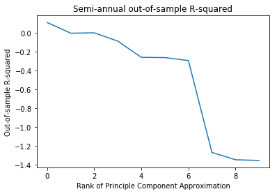

```
x
```

1

```
### 3.1.2.4  Annual $R_{OS}^2$
```

### 3.1.2.4 Annual $R_{OS}^2$

1

1

[output not shown]

1

1

```
processed_df.reset_index().set_index('Dates').resample('Y').agg(lambda x: x[-2]).reset_index()[15:].head()
```

|  | Dates | index | log_DP | inflation | Term_Spread | Default_Spread | MA_1_12 | MA_2_12 | MOMBY_6 | MOMBY_12 | MOM_9 | MOM_12 | output_gap | r_SPX |
| --- | --- | --- | --- | --- | --- | --- | --- | --- | --- | --- | --- | --- | --- | --- |
| 15 | 2006-12-31 | 188 | -3.814893 | -0.004438 | -0.5612 | 0.87 | 1.0 | 1.0 | 1.0 | 1.0 | 1.0 | 1.0 | 0.006390 | 0.016467 |
| 16 | 2007-12-31 | 200 | -3.788723 | 0.003083 | 0.7934 | 0.96 | 1.0 | 1.0 | 1.0 | 1.0 | 1.0 | 1.0 | 0.019589 | -0.044043 |
| 17 | 2008-12-31 | 212 | -3.339371 | -0.008598 | 2.8794 | 3.09 | 0.0 | 0.0 | 1.0 | 1.0 | 0.0 | 0.0 | -0.071761 | -0.074849 |
| 18 | 2009-12-31 | 224 | -3.617410 | 0.003002 | 3.1512 | 1.13 | 1.0 | 1.0 | 1.0 | -1.0 | 1.0 | 1.0 | -0.077893 | 0.057364 |
| 19 | 2010-12-31 | 236 | -3.755558 | 0.003482 | 2.6416 | 1.05 | 1.0 | 1.0 | -1.0 | 1.0 | 1.0 | 1.0 | -0.001713 | -0.002290 |

8

1

```
X_annual = (processed_df.set_index('Dates').resample('Y')
```

2

```
            .agg(lambda x: x[-2])[stock_explanatory_variables].values)
```

3

```
r_annual = (processed_df.set_index('Dates').resample('Y')
```

4

```
            .agg(lambda x: x[-2])['r_SPX'].values)
```

5

```
plt.plot([Rsquared_OS(X_annual,r_annual,i,16) for i in range(X.shape[1]+1)])
```

6

```
plt.xlabel('Rank of Principle Component Approximation')
```

7

```
plt.ylabel('Out-of-sample R-squared')
```

8

```
plt.title('Annual out-of-sample R-squared')
```

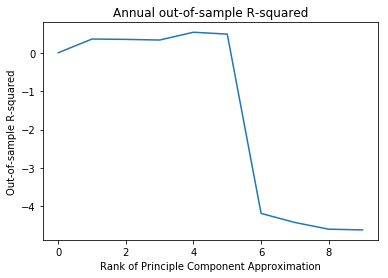

```
xxxxxxxxxx
```

1

[output not shown]

12

1

```
def CW_test(X,r,dim,OS_start):
```

2

```
    denom = len(r) - OS_start
```

3

```
    num = []
```

4

```
    for i in range(OS_start,len(r)):
```

5

```
        X_PCA = truncated_PC(X[:i],dim)
```

6

```
        w = PC_fit(X_PCA,r[:i],dim)
```

7

```
        X_PCA_OS = truncated_PC(X[:i+1],dim)
```

8

```
        r_hat = np.matmul(X_PCA_OS[-1],w)
```

9

```
        num += [(r[i]-r[:i].mean())**2 - (r[i] - r_hat)**2  + (r[:i].mean() - r_hat)**2]
```

10

```
    f_bar = np.array(num).mean()
```

11

```
    CW = np.sqrt(denom) * f_bar / np.std(np.array(num) - f_bar,ddof=1)
```

12

```
    return CW
```

19

1

```
my_dict = {'month':200,'quarter':66,'semi':33,'annual':16}
```

2

3

```
i=0
```

4

```
for item in my_dict.keys():
```

5

```
    plt.figure(i)
```

6

```
    if item == 'month':
```

7

```
        plt.plot([CW_test(X,r,i,my_dict[item]) for i in range(X.shape[1]+1)])
```

8

```
        plt.xlabel('Rank of Principle Component Approximation')
```

9

```
        plt.ylabel('CW test statistics')
```

10

```
        plt.title('Month Clark and Wald Test')
```

11

```
    else:
```

12

```
        eval(f'plt.plot([CW_test(X_{item},r_{item},i,my_dict[item]) for i in range(X.shape[1]+1)])')
```

13

```
        plt.xlabel('Rank of Principle Component Approximation')
```

14

```
        plt.ylabel('CW test statistics')
```

15

```
        if item == 'semi':
```

16

```
            plt.title(f'{item[0].upper()}{item[1:]}' + '-annual Clark and Wald Test')
```

17

```
        else:
```

18

```
            plt.title(f'{item[0].upper()}{item[1:]} Clark and Wald Test')
```

19

```
    i+=1
```

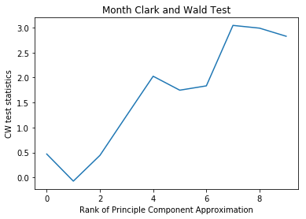

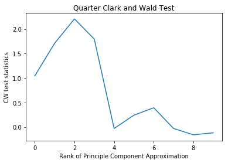

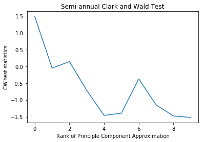

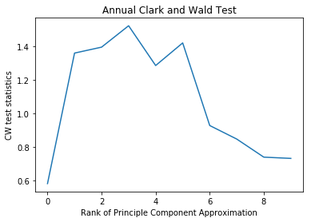

```
xxxxxxxxxx
```

1

```
### 3.2 Bond Returns
```

### 3.2 Bond Returns

```
xxxxxxxxxx
```

1

[output not shown]

3

1

```
stock_explanatory_variables = ['log_DP','inflation','Term_Spread','Default_Spread',\
```

2

```
                               'output_gap','MA_1_12','MA_2_12','MOM_9','MOM_12']
```

3

```
X = processed_df[stock_explanatory_variables].values
```

1

1

```
processed_df.head()
```

|  | Dates | log_DP | inflation | Term_Spread | Default_Spread | MA_1_12 | MA_2_12 | MOMBY_6 | MOMBY_12 | MOM_9 | MOM_12 | output_gap | r_SPX | r_bond | r_bill | y_bond | y_bill |
| --- | --- | --- | --- | --- | --- | --- | --- | --- | --- | --- | --- | --- | --- | --- | --- | --- | --- |
| 0 | 1991-03-29 | -3.184739 | 0.000742 | 2.128 | 1.16 | 1.0 | 1.0 | 1.0 | 1.0 | 1.0 | 1.0 | 0.003305 | 0.022203 | -0.049669 | -0.049669 | 0.0574 | 0.0574 |
| 1 | 1991-04-30 | -3.187664 | 0.000000 | 2.326 | 1.08 | 1.0 | 1.0 | 1.0 | 1.0 | 1.0 | 1.0 | 0.008409 | 0.000346 | -0.040070 | -0.040070 | 0.0551 | 0.0551 |
| 2 | 1991-05-31 | -3.221650 | 0.002226 | 2.366 | 1.00 | 1.0 | 1.0 | 1.0 | 1.0 | 1.0 | 1.0 | 0.015507 | 0.038577 | 0.003630 | 0.003630 | 0.0553 | 0.0553 |
| 3 | 1991-06-28 | -3.175793 | 0.003701 | 2.534 | 0.95 | 1.0 | 1.0 | -1.0 | 1.0 | 1.0 | 1.0 | 0.018247 | -0.047893 | 0.001808 | 0.001808 | 0.0554 | 0.0554 |
| 4 | 1991-07-31 | -3.222907 | 0.002950 | 2.471 | 0.89 | 1.0 | 1.0 | -1.0 | 1.0 | 1.0 | 1.0 | 0.014082 | 0.044859 | -0.001805 | -0.001805 | 0.0553 | 0.0553 |

1

1

1

1

1

1

1

1

```
xxxxxxxxxx
```

1

```
Work in progress
```

Work in progress

1

1

1

1

1

1